# Exercice 5_Tohon aurelas

Tohon Aurelas

31/07/2020

# Création d’une série temporelle du CO2 à partir des données de hawai.csv

```r
library("tidyverse")
hawai <- read_csv("data/hawai.csv")
View(hawai)
library("forecast")
library("fpp2")
library(lubridate)
library(zoo)
```

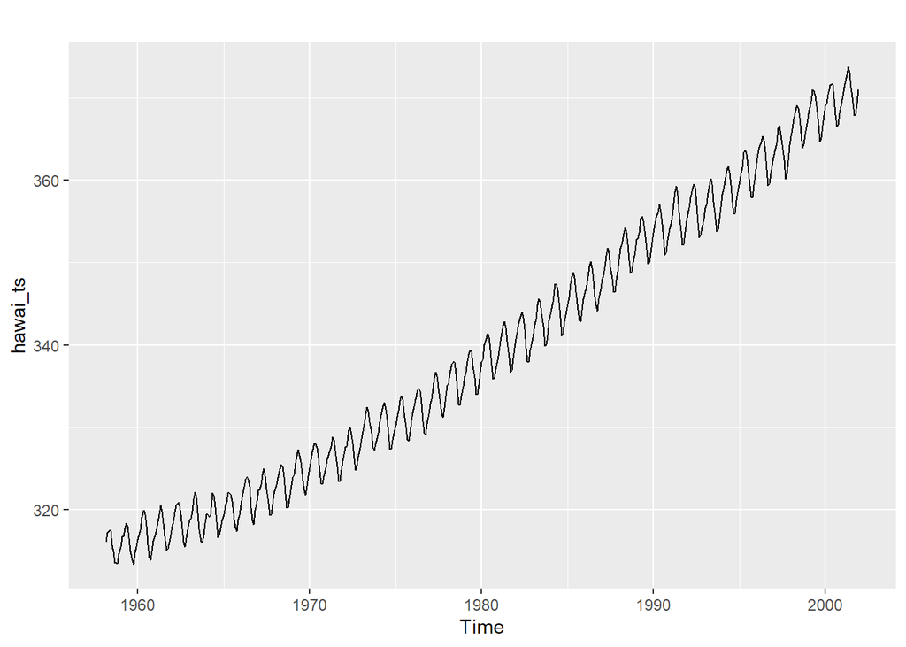

```r
hawai_ts <- ts(hawai %>% dplyr::select(-time),
                    start = c(hawai$time[1] , 1),
                    frequency = 12)
autoplot(hawai_ts)
```

# 2. séparation de la série en parties d’entraînement (environ 70% des données) et en partie test

Nous allons prendre 70% des données. Cela correstpond à la période de 1958 à 1988 Ici, la serie qui sera en partie d’entrainement est hawai_ts_train et la serie hawai_ts_test en partie test

```r
hawai70_ts <- hawai_ts[, 1]
hawai_ts_train <- window(hawai_ts, start = 1958.167, end = 1988.999)
hawai_ts_test <- window(hawai_ts, start = 1989.000)
```

# 3. création d’un modèle prévisionnel sur les données d’entraînement, puis projection de la prévision de CO2 atmosphérique pour comparer aux données test

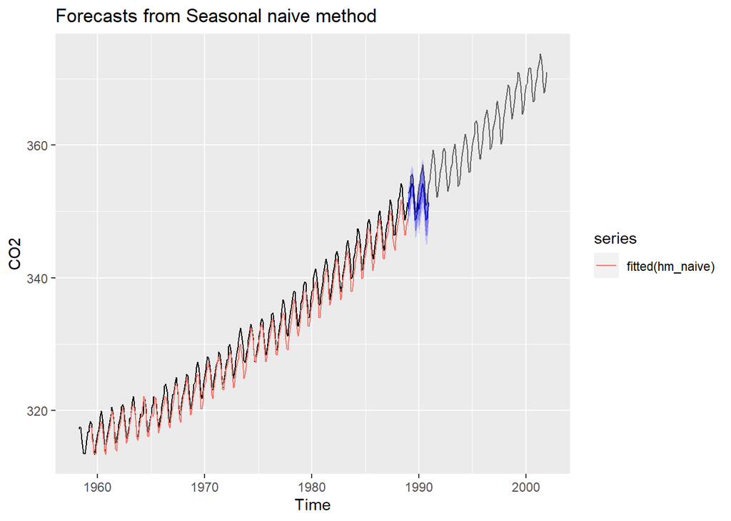

```r
hm_naive <- snaive(hawai_ts_train, h = 24)
autoplot(hm_naive) +
  autolayer(fitted(hm_naive)) +
  autolayer(hawai_ts_test, color = rgb(0, 0, 0, 0.6)) +
  labs(x = "Time", y = "CO2")
```

# 4. Analyse des résidus

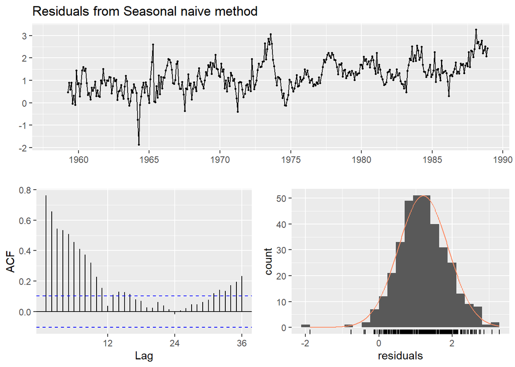

```
##
##  Ljung-Box test
##
## data:  Residuals from Seasonal naive method
## Q* = 954.5, df = 24, p-value < 2.2e-16
##
## Model df: 0.   Total lags used: 24
```

```r
checkresiduals(hm_naive)
```

La p-value étant inférieure à 2.2e-16, il apparait ainsi tres peu probable que les résidus forment un bruit blanc. Les résidus contiennent donc de l’autocorrélation. Le graphique de la distribution des résidus montre quelques valeurs aberrantes, ainsi qu’une distribution plutôt pointue (un test de Kurtosis serait probablement élevé) étalée vers la droite.

# 5. commentaire de la fiabilité du modele. Proposition d’amélioration

```r
accuracy(hm_naive, hawai_ts)
```

```
##                    ME     RMSE      MAE       MPE      MAPE     MASE      ACF1
## Training set 1.206429 1.382741 1.228940 0.3612373 0.3682565 1.000000 0.7616068
## Test set     2.057708 2.181601 2.057708 0.5815549 0.5815549 1.674376 0.6514169
##              Theil's U
## Training set        NA
## Test set      1.754403
```

Nos resultats indiquent qu’il existerait une structure dans les r?sidus. En consequence, un meilleur modele permettrait de le voir plus clairement.